# Silvia Kruse - Hausaufgabe 2

```r
library(tidyverse)
```

```r
(books <- BX_Books %>%
  select(ISBN,`Book-Title`,`Book-Author`,`Year-Of-Publication`,Publisher))
```

| ISBN | Book-Title | Book-Author | Year-Of-Publication | Publisher |
| --- | --- | --- | --- | --- |
| 0195153448 | Classical Mythology | Mark P. O. Morford | 2002 | Oxford University Press |
| 0002005018 | Clara Callan | Richard Bruce Wright | 2001 | HarperFlamingo Canada |
| 0060973129 | Decision in Normandy | Carlo D'Este | 1991 | HarperPerennial |
| 0374157065 | Flu: The Story of the Great Influenza Pandemic of 1918 and the Search for the Virus That Caused It | Gina Bari Kolata | 1999 | Farrar Straus Giroux |
| 0393045218 | The Mummies of Urumchi | E. J. W. Barber | 1999 | W. W. Norton &amp; Company |
| 0399135782 | The Kitchen God's Wife | Amy Tan | 1991 | Putnam Pub Group |
| 0425176428 | What If?: The World's Foremost Military Historians Imagine What Might Have Been | Robert Cowley | 2000 | Berkley Publishing Group |
| 0671870432 | PLEADING GUILTY | Scott Turow | 1993 | Audioworks |
| 0679425608 | Under the Black Flag: The Romance and the Reality of Life Among the Pirates | David Cordingly | 1996 | Random House |
| 074322678X | Where You'll Find Me: And Other Stories | Ann Beattie | 2002 | Scribner |

[output cut: 990 more lines]

```r
(users <- BX_Users %>%
  mutate(Age = as.numeric(Age)))
```

```
Problem with `mutate()` input `Age`.
i NAs durch Umwandlung erzeugt
i Input `Age` is `as.numeric(Age)`.NAs durch Umwandlung erzeugt
```

| User-ID | Location | Age |
| --- | --- | --- |
| 1 | nyc, new york, usa | NA |
| 2 | stockton, california, usa | 18 |
| 3 | moscow, yukon territory, russia | NA |
| 4 | porto, v.n.gaia, portugal | 17 |
| 5 | farnborough, hants, united kingdom | NA |
| 6 | santa monica, california, usa | 61 |
| 7 | washington, dc, usa | NA |
| 8 | timmins, ontario, canada | NA |
| 9 | germantown, tennessee, usa | NA |
| 10 | albacete, wisconsin, spain | 26 |

[output cut: 990 more lines]

```r
(ratings <- BX_Book_Ratings %>%
  left_join(BX_Books))
```

| User-ID | ISBN | Book-Rating | Book-Title | Book-Author | Year-Of-Publication | Publisher | Image-URL-S | Image-URL-M | Image-URL-L |
| --- | --- | --- | --- | --- | --- | --- | --- | --- | --- |
| 276725 | 034545104X | 0 | Flesh Tones: A Novel | M. J. Rose | 2002 | Ballantine Books | http://images.amazon.com/images/P/034545104X.01.THUMBZZZ.jpg | http://images.amazon.com/images/P/034545104X.01.MZZZZZZZ.jpg | http://images.amazon.com/images/P/034545104X.01.LZZZZZZZ.jpg |
| 276726 | 0155061224 | 5 | Rites of Passage | Judith Rae | 2001 | Heinle | http://images.amazon.com/images/P/0155061224.01.THUMBZZZ.jpg | http://images.amazon.com/images/P/0155061224.01.MZZZZZZZ.jpg | http://images.amazon.com/images/P/0155061224.01.LZZZZZZZ.jpg |
| 276727 | 0446520802 | 0 | The Notebook | Nicholas Sparks | 1996 | Warner Books | http://images.amazon.com/images/P/0446520802.01.THUMBZZZ.jpg | http://images.amazon.com/images/P/0446520802.01.MZZZZZZZ.jpg | http://images.amazon.com/images/P/0446520802.01.LZZZZZZZ.jpg |
| 276729 | 052165615X | 3 | Help!: Level 1 | Philip Prowse | 1999 | Cambridge University Press | http://images.amazon.com/images/P/052165615X.01.THUMBZZZ.jpg | http://images.amazon.com/images/P/052165615X.01.MZZZZZZZ.jpg | http://images.amazon.com/images/P/052165615X.01.LZZZZZZZ.jpg |
| 276729 | 0521795028 | 6 | The Amsterdam Connection : Level 4 (Cambridge English Readers) | Sue Leather | 2001 | Cambridge University Press | http://images.amazon.com/images/P/0521795028.01.THUMBZZZ.jpg | http://images.amazon.com/images/P/0521795028.01.MZZZZZZZ.jpg | http://images.amazon.com/images/P/0521795028.01.LZZZZZZZ.jpg |
| 276733 | 2080674722 | 0 | Les Particules Elementaires | Michel Houellebecq | 1998 | Flammarion | http://images.amazon.com/images/P/2080674722.01.THUMBZZZ.jpg | http://images.amazon.com/images/P/2080674722.01.MZZZZZZZ.jpg | http://images.amazon.com/images/P/2080674722.01.LZZZZZZZ.jpg |
| 276736 | 3257224281 | 8 | NA | NA | NA | NA | NA | NA | NA |
| 276737 | 0600570967 | 6 | NA | NA | NA | NA | NA | NA | NA |
| 276744 | 038550120X | 7 | A Painted House | JOHN GRISHAM | 2001 | Doubleday | http://images.amazon.com/images/P/038550120X.01.THUMBZZZ.jpg | http://images.amazon.com/images/P/038550120X.01.MZZZZZZZ.jpg | http://images.amazon.com/images/P/038550120X.01.LZZZZZZZ.jpg |
| 276745 | 342310538 | 10 | NA | NA | NA | NA | NA | NA | NA |

[output cut: 990 more lines]

Aufgabe 1. Gibt es eine lineare Beziehung zwischen Anzahl Bücher pro Publisher und Anzahl Ratings, die die Bücher eines Publishers erhalten? (hier müssen Sie wieder etwas Data Wrangling betreiben)

Um diese Frage zu beantworten sind die Anzahl an Büchern eines Verlages sowie die Gesamtzahl der Ratings für diesen Verlag notwendig. Dazu habe ich zunächst sowohl die Tabelle books als auch die Tabelle ratings, ähnlich wie bei der letzten Aufgabe, nach den Publishern sortiert und lediglich die jeweiligen Anzahlen (an Büchern oder Ratings) zusammengefasst.

Diese Anzahl-Werte habe ich danach mit Hilfe eines join kombiniert und die neue Tabelle publisher mit allen relevanten Werten erstellt. Dabei ist mir aufgefallen, dass gerade die größten Verlage mehr Bücher als Bewertungen haben. Sprich viele Bücher keine Bewertungen erhalten haben. Diese Tatsache würde der Aussage der Aufgabe 1 also schon widersprechen. Ich war mir unsicher, ob diese Verlage evtl. rausgerechnet werden sollten (weil vielleicht mit den Daten etwas nicht stimmt?). Deshalb habe ich eine Filter-Funktion eingebaut, die momentan durch einen Kommentar deaktiviert ist.

Im Anschluss habe ich einen Plot erstellt und eine lineare Regression durchgeführt.

```r
(books_neu <- books %>%
  group_by(Publisher) %>%
  summarise(Anzahl = n()) %>%
  arrange(desc(Anzahl)))
```

| Publisher | Anzahl |
| --- | --- |
| Harlequin | 7535 |
| Silhouette | 4220 |
| Pocket | 3905 |
| Ballantine Books | 3783 |
| Bantam Books | 3646 |
| Scholastic | 3160 |
| Simon &amp; Schuster | 2971 |
| Penguin Books | 2844 |
| Berkley Publishing Group | 2771 |
| Warner Books | 2727 |

[output cut: 990 more lines]

```r
(ratings_neu <- ratings %>%
  group_by(`Publisher`) %>%
  filter(`Book-Rating` > 0) %>%
  summarise(AnzahlBewertungen = n() ) %>%
  arrange(desc(AnzahlBewertungen)) %>%
  drop_na())
```

| Publisher | AnzahlBewertungen |
| --- | --- |
| Ballantine Books | 12781 |
| Pocket | 10567 |
| Berkley Publishing Group | 9321 |
| Warner Books | 9032 |
| Bantam | 7383 |
| Bantam Books | 7304 |
| Penguin Books | 7020 |
| Signet Book | 6775 |
| Perennial | 5775 |
| Avon | 5565 |

[output cut: 990 more lines]

```r
(publisher <- left_join(books_neu, ratings_neu, by="Publisher")) #%>%
```

| Publisher | Anzahl | AnzahlBewertungen |
| --- | --- | --- |
| Harlequin | 7535 | 5026 |
| Silhouette | 4220 | 3226 |
| Pocket | 3905 | 10567 |
| Ballantine Books | 3783 | 12781 |
| Bantam Books | 3646 | 7304 |
| Scholastic | 3160 | 4284 |
| Simon &amp; Schuster | 2971 | 3953 |
| Penguin Books | 2844 | 7020 |
| Berkley Publishing Group | 2771 | 9321 |
| Warner Books | 2727 | 9032 |

[output cut: 990 more lines]

```r
  #filter (AnzahlBewertungen>Anzahl))
```

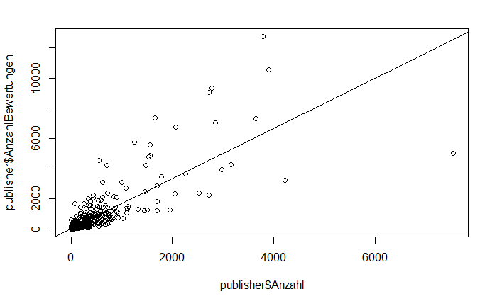

```r
fit <- lm(publisher$AnzahlBewertungen~publisher$Anzahl)

plot(publisher$Anzahl, publisher$AnzahlBewertungen)

abline(fit)
```

Die Bewertung der linearen Regression liefert folgende Ergebnisse: Multiple R-squared: 0.6832, Adjusted R-squared: 0.6831 Diese würde ich als “OK” bewerten, jedoch ist die lineare Regression nicht absolut aussagekräftig und die Frage, ob die Anzahl an Büchern eines Verlages mit den Bewertungen pro Verlag linear ansteigt, kann meiner Meinung nach nicht vollkommen zufriedenstellend beantworetet werden.

Wenn man, wie oben bereits beschrieben die Verlage herausfiltert, die mehr Bücher als Ratings haben, werden bessere R-Werte berechnet: Multiple R-squared: 0.843, Adjusted R-squared: 0.8429  
Allerdings weiß ich nicht, ob dies nicht eine Verfälschung der Ergebnisse wäre.

```r
summary(fit)
```

```
Call:
lm(formula = publisher$AnzahlBewertungen ~ publisher$Anzahl)

Residuals:
    Min      1Q  Median      3Q     Max
-7528.8    -1.0     3.6     4.3  6480.2

Coefficients:
                 Estimate Std. Error t value Pr(>|t|)
(Intercept)      -4.96083    1.63797  -3.029  0.00246 **
publisher$Anzahl  1.66686    0.01055 158.010  < 2e-16 ***
---
Signif. codes:  0 ‘***’ 0.001 ‘**’ 0.01 ‘*’ 0.05 ‘.’ 0.1 ‘ ’ 1

Residual standard error: 174.3 on 11579 degrees of freedom
  (5241 observations deleted due to missingness)
Multiple R-squared:  0.6832,    Adjusted R-squared:  0.6831
F-statistic: 2.497e+04 on 1 and 11579 DF,  p-value: < 2.2e-16
```

Aufgabe 2. Haben ältere Bücher mehr Ratings, weil sie mehr Zeit haben, um Ratings zu sammeln? (muss nicht unbedingt mit einer linearen Regression analysiert werden)

Um diese Aufgabe zu lösen, habe ich erneut eine neue Tabelle erstellt, welche die Publikationsjahre eines Buches sowie seine Rating-Anzahl verzeichnet. Anschließend wollte ich erneut einen Plot anwenden, um die Verteilung der Datenpunkt zu überprüfen.

Dabei sind mir einige Ungereimtheiten in den Daten aufgefallen, die ich herausgefiltert habe: 1. Einige Bücher waren mit dem Jahr 0 angegeben. Um den Plot übersichtlich zu gestalten habe ich außerdem die wenigen Titel, die vor 1850 erschienen sind herausgefiltert. 2. Einige Bücher waren mit Jahren nach 2020 angegeben. Auch diese habe ich herausgefiltert. 3. Außerdem habe ich 2 Titel herausgenommen, die über 1000 Bewertungen hatten. Dies habe ich nur gemacht, um den Plot möglichst übersichtlich zu gestalten. (Vermutlich nicht notwendig)

```r
(books_neu2 <- ratings %>%
  group_by(`Book-Title`, `Year-Of-Publication`) %>%
  summarise(AnzahlBewertungenBuch = n()) %>%
  arrange(desc(AnzahlBewertungenBuch))%>%
  drop_na()%>%
  filter(`Year-Of-Publication`> 1850)%>%
  filter(`Year-Of-Publication`< 2021)%>%
  filter(AnzahlBewertungenBuch < 1000))
```

| Book-Title | Year-Of-Publication | AnzahlBewertungenBuch |
| --- | --- | --- |
| The Da Vinci Code | 2003 | 897 |
| A Painted House | 2001 | 835 |
| Divine Secrets of the Ya-Ya Sisterhood: A Novel | 1997 | 732 |
| The Red Tent (Bestselling Backlist) | 1998 | 723 |
| The Summons | 2002 | 654 |
| Snow Falling on Cedars | 1995 | 620 |
| The Testament | 1999 | 616 |
| The Secret Life of Bees | 2003 | 615 |
| Angels &amp; Demons | 2001 | 586 |
| Where the Heart Is (Oprah's Book Club (Paperback)) | 1998 | 585 |

[output cut: 990 more lines]

Im Anschluss habe ich einen Plot durchgeführt. An der Verteilung der Datenpunkte kann man erkennen, dass die Annahme aus Aufgabe 2 nicht stimmt. Das Gegenteil ist eher der Fall, denn je neuer ein Titel ist, um so mehr Bewertungen scheint er zu haben (ablesbar aus dem Plot).

```r
fit2 <- lm(books_neu2$AnzahlBewertungenBuch~books_neu2$`Year-Of-Publication`)

(plot(books_neu2$`Year-Of-Publication`, books_neu2$AnzahlBewertungenBuch))
```

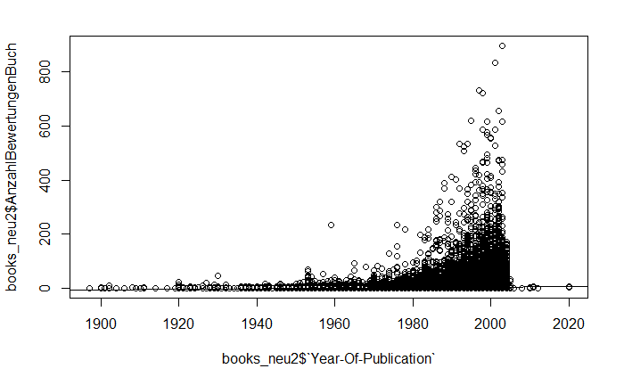

```r
abline(fit2)
```

```r
(summary(fit2))
```

```
Call:
lm(formula = books_neu2$AnzahlBewertungenBuch ~ books_neu2$`Year-Of-Publication`)

Residuals:
   Min     1Q Median     3Q    Max
 -4.59  -3.10  -2.19  -0.79 892.25

Coefficients:
                                   Estimate Std. Error t value Pr(>|t|)
(Intercept)                      -1.825e+02  6.313e+00  -28.92   <2e-16 ***
books_neu2$`Year-Of-Publication`  9.351e-02  3.166e-03   29.53   <2e-16 ***
---
Signif. codes:  0 ‘***’ 0.001 ‘**’ 0.01 ‘*’ 0.05 ‘.’ 0.1 ‘ ’ 1

Residual standard error: 13.17 on 261129 degrees of freedom
Multiple R-squared:  0.003328,  Adjusted R-squared:  0.003325
F-statistic: 872.1 on 1 and 261129 DF,  p-value: < 2.2e-16
```